# PCA: the shape hidden in your data

The geometry behind principal component analysis: how the covariance matrix encodes the shape of your data, and why eigenvectors are the natural axes to read it from.

8 May 2026

An NBA scout records three measurements for every player he is scouting: height, wingspan and reach. All three measures are highly correlated, because taller players tend to have longer wingspans and higher reaches. So in practice there are three numbers (dimensions) per player, but the data could be represented with a single dimension representing the “overall size” of the NBA player. PCA finds this dimension automatically from the data alone.

Listing 1: Synthetic NBA player data generation

**How the data was generated**

```python
rng = np.random.default_rng(42)
N = 220

feature_names = ["Height", "Wingspan", "Standing reach"]
means = np.array([200.0, 205.0, 260.0])  # cm
stds = np.array([8.0, 9.0, 11.0])  # cm

# Correlation matrix: positively correlated but not perfectly
corr = np.array(
    [
        [1.00, 0.75, 0.68],
        [0.75, 1.00, 0.62],
        [0.68, 0.62, 1.00],
    ]
)

L = np.linalg.cholesky(corr)
Z = rng.standard_normal((N, 3)) @ L.T
X_raw = Z * stds + means
```

## Standardising the data

For computing the PCA components, we need the covariance matrix. Before computing it, we standardize each feature, so the PCA runs on the correlation matrix. The data points are standardized as

$$x_{ij} \leftarrow \frac{x_{ij} - \mu_j}{\sigma_j}$$

where $i$ indexes the player and $j$ indexes the feature (height, wingspan, or standing reach), $\mu_j$ is the mean of feature $j$ across all players, and $\sigma_j$ is its standard deviation.

This step makes each variable have a mean of 0 and variance of 1. This makes the three axes comparable because otherwise the feature with the largest spread (standing reach, 11 cm) would dominate the covariance matrix. The shape of the correlation stays unchanged because standardisation only rescales the values and doesn’t distort them.

## The covariance matrix: encoding shape

After standardising the three measurements, the sample covariance matrix is computed as:

$$\Sigma = \frac{1}{N-1} X^\top X$$

This form holds because $X$ is already centered. Since each feature also has variance 1, the diagonal entries of $\Sigma$ are all 1 and the off-diagonal entries are Pearson correlation coefficients. For standardized data, the covariance matrix and the correlation matrix are the same thing. Geometrically the covariance matrix encodes the shape of the data cloud. Looking at Listing 1, you can see that the sample covariance matrix is basically the same that was used to generate the synthetic data. You can see the resulting covariance matrix from Figure 2.

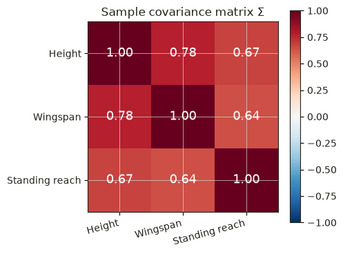

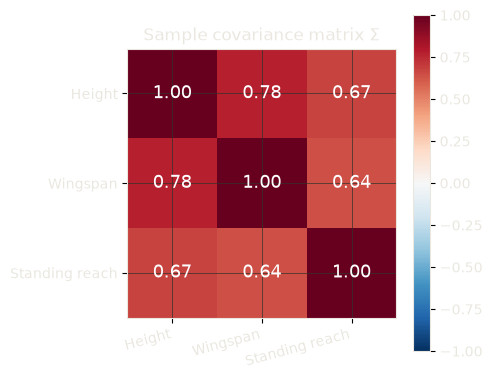

Figure 2: Sample covariance matrix of the three standardised measurements (shown as a heatmap). High off-diagonal values confirm that all three features co-vary strongly.

## Eigenvectors: the natural axes of the data

An eigenvector $\mathbf{v}$ of $\Sigma$ satisfies

$$\Sigma \mathbf{v} = \lambda \mathbf{v}$$

Applying the matrix $\Sigma$ to $\mathbf{v}$ only scales the vector by a scalar $\lambda$ and never rotates it. These eigenvectors are natural axes for the data cloud. These eigenvectors are directions along which the data is uncorrelated, with no covariance between them (orthogonal with respect to each other). The corresponding eigenvalue $\lambda$ is the variance of the data projected onto that axis. Then sorting the eigenvalues $\lambda$ from largest to smallest gives us the principal components in order: PC1 explains most of the variance, PC2 the next most etc. All principal components are orthogonal to each other. The full decomposition is:

$$\Sigma = V \Lambda V^\top$$

where $V = [\mathbf{v}_1 \mid \mathbf{v}_2 \mid \mathbf{v}_3]$ has the eigenvectors as columns and $\Lambda = \text{diag}(\lambda_1, \lambda_2, \lambda_3)$.

**Computing the principal components**

```python
eigenvalues, eigenvectors = np.linalg.eigh(Sigma)

# eigh returns ascending order — reverse to descending
idx = np.argsort(eigenvalues)[::-1]
eigenvalues = eigenvalues[idx]
eigenvectors = eigenvectors[:, idx]  # columns are PC vectors

explained_var = eigenvalues / eigenvalues.sum()
cumulative_var = np.cumsum(explained_var)

print(f"Eigenvalues:       {np.round(eigenvalues, 3)}")
print(f"Explained variance:{np.round(explained_var, 3)}")
print(f"\nPC1: {np.round(eigenvectors[:, 0], 3)}")
print(f"PC2: {np.round(eigenvectors[:, 1], 3)}")
print(f"PC3: {np.round(eigenvectors[:, 2], 3)}")
```

```
Eigenvalues:       [2.402 0.385 0.227]
Explained variance:[0.797 0.128 0.075]

PC1: [-0.592 -0.585 -0.555]
PC2: [-0.314 -0.466  0.827]
PC3: [-0.742  0.664  0.092]
```

## Explained variance and the scree plot

Each eigenvalue $\lambda_i$ is the variance of the data projected onto PC$i$. Thus the fraction of total variance explained by PC$i$ is $\lambda_i / \sum_j \lambda_j$. Figure 4 shows these fractions in descending order.

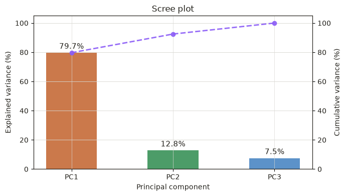

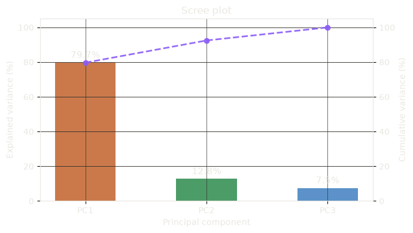

Figure 4: Scree plot. Bars show individual explained variance per principal component; the line shows the cumulative total. In this dataset PC1 alone captures most of the variance. PC1 is able to capture the general "size" component.

## Dimensionality reduction

Keeping only the first $k$ principal components gives a rank-$k$ approximation of the data:

$$\underbrace{Z_k}_{N \times k} = \underbrace{X}_{N \times p}\underbrace{V_k}_{p \times k}, \qquad \underbrace{\hat{X}}_{N \times p} = \underbrace{Z_k}_{N \times k}\underbrace{V_k^\top}_{k \times p}$$

where $V_k$ contains only the first $k$ eigenvectors and $p$ is the number of features (3 in this case). In practice, the data is first projected down to $k$ dimensions, then reconstructed back into the original $p$-dimensional space. But during the reconstruction, the data is constrained to lie on a $k$-dimensional subspace, so information carried by the discarded eigenvalues is lost. Scaled by $\frac{1}{N-1}$ like the covariance matrix, the reconstruction error is exactly the sum of these discarded eigenvalues:

$$\frac{1}{N-1}\|X - \hat{X}\|_F^2 = \sum_{i > k} \lambda_i$$

## What the scout found

PC1 captures most of the variation (~80%, see Figure 4) of the three measurements. PC1 can be thought of as an “overall size” axis. PC2 and PC3 capture the remaining ~20% of the variation. What I like about PCA is that all of this analysis could be done automatically with only the data set and a little linear algebra.